# Predicting How Well a Dumbbell Curl Is Done

Practical Machine Learning course project

28 October 2026

## Overview

The question is whether wearable sensors can tell a correct dumbbell curl from four common mistakes. This report cleans the sensor data, compares a single classification tree with a random forest using 5-fold cross-validation, estimates the forest’s out-of-sample error on a held-back validation set, and then checks how well the model carries over to a person it has never seen. The conclusion collects the numbers.

## Data

Six participants did sets of ten dumbbell biceps curls in five ways while sensors on the belt, upper arm, forearm and dumbbell recorded their movement (Velloso et al., 2013). Class A is the correct technique. The others are common mistakes: throwing the elbows to the front (B), lifting only halfway (C), lowering only halfway (D) and throwing the hips to the front (E). Each row of the data is one reading taken from the continuous sensor stream.

```r
urls <- c("https://d396qusza40orc.cloudfront.net/predmachlearn/pml-training.csv",
          "https://d396qusza40orc.cloudfront.net/predmachlearn/pml-testing.csv")
files <- file.path("data", basename(urls))
dir.create("data", showWarnings = FALSE)
for (i in seq_along(urls)) {
  if (!file.exists(files[i])) download.file(urls[i], files[i], mode = "wb")
}

na_strings <- c("NA", "", "#DIV/0!")
raw  <- read.csv(files[1], na.strings = na_strings)
test <- read.csv(files[2], na.strings = na_strings)
dim(raw)
```

```
## [1] 19622   160
```

```r
dim(test)
```

```
## [1]  20 160
```

```r
table(raw$classe)
```

```
##
##    A    B    C    D    E
## 5580 3797 3422 3216 3607
```

## Choosing the predictors

Of the 159 candidate columns, only 52 are usable. Two groups go.

**Window summaries.** The sensors’ stream was cut into short time windows, and 100 columns hold statistics for each window (kurtosis, skewness, maximum, variance and so on). They are filled in only on the 406 rows that close a window and are empty on all 20 test rows, so a model could never use them at prediction time.

```r
na_share <- colMeans(is.na(raw))
table(cut(na_share, c(-Inf, 0, 0.97, 1),
          labels = c("no missing values", "up to 97% missing", "over 97% missing")))
```

```
##
## no missing values up to 97% missing  over 97% missing
##                60                 0               100
```

**Bookkeeping columns.** The first seven columns describe the recording, not the movement, and some of them leak the answer. `X` is the row number, and the file is sorted by class, so `X` separates the classes perfectly in the training data and means nothing anywhere else:

```r
tapply(raw$X, raw$classe, range)
```

```
## $A
## [1]    1 5580
##
## $B
## [1] 5581 9377
##
## $C
## [1]  9378 12799
##
## $D
## [1] 12800 16015
##
## $E
## [1] 16016 19622
```

```r
mean(test$num_window %in% raw$num_window)
```

```
## [1] 1
```

The window number is just as dangerous. Every test row comes from a window that also appears in the training file, so looking up `num_window` would score 20 out of 20 on the quiz while learning nothing about how anyone lifts. The timestamps play the same role. The participant’s name is dropped too, so the model has to rely on the sensors.

```r
bookkeeping <- c("X", "user_name", "raw_timestamp_part_1", "raw_timestamp_part_2",
                 "cvtd_timestamp", "new_window", "num_window")
predictors <- setdiff(names(raw)[na_share == 0], c(bookkeeping, "classe"))
data <- data.frame(raw[predictors], classe = factor(raw$classe))

length(predictors)
```

```
## [1] 52
```

```r
length(nearZeroVar(data[predictors]))
```

```
## [1] 0
```

The 52 predictors that remain are the roll, pitch, yaw and total acceleration of each of the four sensors, plus their x, y and z gyroscope, accelerometer and magnetometer readings. None has near-zero variance, so no further filtering is needed.

## Cross-validation design

The data is used in two layers so that the final error estimate is honest.

1. **A validation set.** 25% of the rows, stratified by class, are set aside before any modelling. They are used once, at the end, to estimate the out-of-sample error of the chosen model.
2. **5-fold cross-validation** on the other 75% picks the model and tunes it. Both models below use the same five folds, so their scores are directly comparable.

Five folds is a practical middle ground. Each fold still trains on about 11,800 rows, so the estimate is not pessimistic, and it costs half the model fits of 10-fold cross-validation, which matters for a random forest.

```r
set.seed(2026)
in_fit <- createDataPartition(data$classe, p = 0.75, list = FALSE)
fit_set    <- data[in_fit, ]
validation <- data[-in_fit, ]
folds <- createFolds(fit_set$classe, k = 5, returnTrain = TRUE)
ctrl  <- trainControl(method = "cv", index = folds)
c(fit_set = nrow(fit_set), validation = nrow(validation))
```

```
##    fit_set validation
##      14718       4904
```

## Models

**Baseline: a single classification tree.** A tree is easy to read and sets a floor. Its complexity parameter `cp` is tuned over ten values.

**Main model: a random forest.** The boundaries between the classes are unlikely to be simple. A mistake such as throwing the hips forward shows up as a combination of belt, arm and dumbbell movement, and many of the 52 readings are strongly correlated with each other. A random forest handles nonlinear boundaries, interactions and correlated inputs without scaling or feature engineering, and averaging many trees makes it far more stable than one tree. The number of predictors tried at each split, `mtry`, is tuned over 2, 7 (close to the usual default of √52), 14 and 27. Each forest has 150 trees.

```r
tree_fit <- train(classe ~ ., data = fit_set, method = "rpart",
                  tuneLength = 10, trControl = ctrl)

set.seed(2026)
rf_fit <- train(classe ~ ., data = fit_set, method = "rf", ntree = 150,
                tuneGrid = data.frame(mtry = c(2, 7, 14, 27)), trControl = ctrl)
```

```r
knitr::kable(data.frame(
  model = c("Classification tree", "Random forest"),
  best_setting = c(sprintf("cp = %.4f", tree_fit$bestTune$cp),
                   sprintf("mtry = %d", rf_fit$bestTune$mtry)),
  cv_accuracy = pct(c(max(tree_fit$results$Accuracy), max(rf_fit$results$Accuracy)), 2)
), col.names = c("Model", "Best setting", "5-fold CV accuracy"))
```

| Model | Best setting | 5-fold CV accuracy |
| --- | --- | --- |
| Classification tree | cp = 0.0140 | 69.26% |
| Random forest | mtry = 7 | 99.42% |

The tree gets 69% of the readings right and the forest almost all of them, so the forest is the model carried forward. Figure 1 shows that `mtry` barely matters. Every value tried scores at least 99.1%, and the best and worst differ by 0.32 percentage points (note the narrow y axis). The forest’s own out-of-bag error is already 0.74% at 50 trees and 0.50% at 150, so more trees would not change the result.

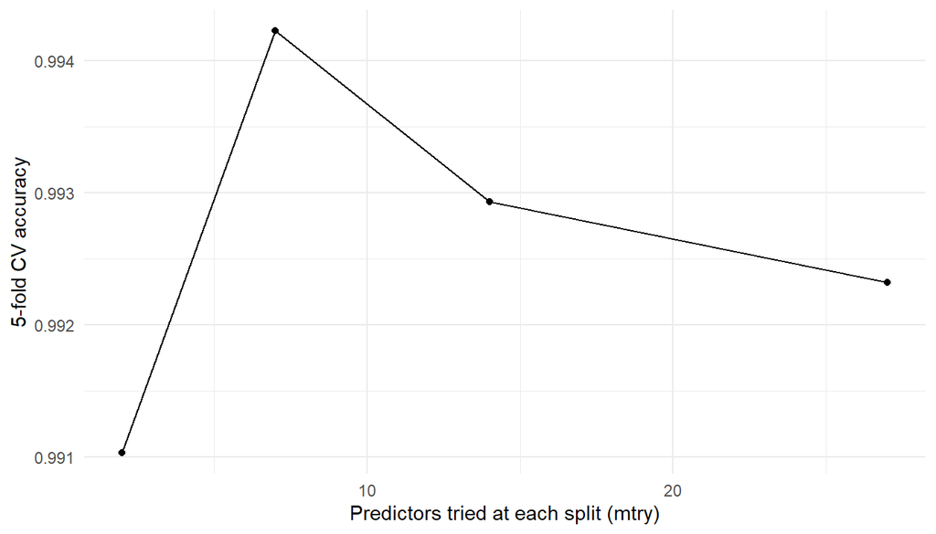

Figure 1. Cross-validated accuracy of the random forest for each value of mtry.

```r
ggplot(rf_fit) +
  labs(x = "Predictors tried at each split (mtry)", y = "5-fold CV accuracy") +
  theme_minimal()
```

Figure 2 shows which readings the forest leans on most.

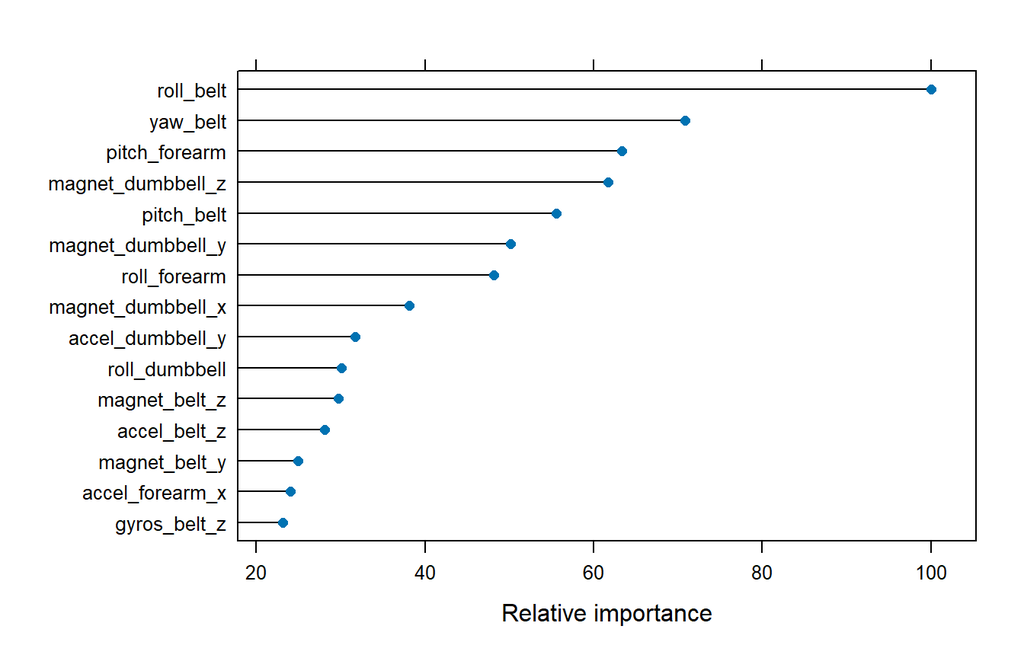

Figure 2. The 15 most important predictors (mean decrease in Gini impurity, scaled to 100).

```r
importance <- varImp(rf_fit)
top_three <- head(rownames(importance$importance)[order(-importance$importance$Overall)], 3)
plot(importance, top = 15, xlab = "Relative importance")
```

The three most important are `roll_belt`, `yaw_belt`, and `pitch_forearm`.

## Expected out-of-sample error

The chosen forest now predicts the validation set, which played no part in fitting or tuning.

```r
cm <- confusionMatrix(predict(rf_fit, validation), validation$classe)
cm$table
```

```
##           Reference
## Prediction    A    B    C    D    E
##          A 1395    7    0    0    0
##          B    0  941    4    0    0
##          C    0    1  850    5    2
##          D    0    0    1  798    1
##          E    0    0    0    1  898
```

```r
accuracy    <- unname(cm$overall["Accuracy"])
accuracy_ci <- unname(cm$overall[c("AccuracyLower", "AccuracyUpper")])
oos_error   <- 1 - accuracy
tree_accuracy <- mean(predict(tree_fit, validation) == validation$classe)
```

Validation accuracy is **99.55%**, so the estimated out-of-sample error is **0.45%**, with a 95% confidence interval of 0.28% to 0.68%. Sensitivity is between 99.2% and 100.0% across the five classes, so no single mistake type is being missed. The cross-validation estimate, 99.42%, agrees, which is a sign the model was not overfitted to the folds. The tree, for comparison, scores 68.1% on the same rows.

With an error rate this low, the chance of getting all 20 test cases right is roughly (1 − 0.0045)<sup>20</sup> ≈ 91%.

One caveat shapes how far this number reaches. The readings are a continuous stream, so for almost every validation row, the readings taken a split second before and after it are in the training set. That makes the task easier than classifying a fresh recording. It is also exactly the situation of the 20 test cases, whose windows all appear in the training data, so the estimate is the right one for them.

## How well does this carry over to a new person?

To see how the model would do on someone it has never seen, the forest is refitted six times, each time leaving out one participant entirely and then predicting that person’s readings. It uses the tuned `mtry` and 150 trees.

```r
subjects <- raw$user_name
set.seed(2026)
loso_accuracy <- sapply(sort(unique(subjects)), function(s) {
  held_out <- subjects == s
  model <- randomForest(classe ~ ., data = data[!held_out, ], ntree = 150,
                        mtry = rf_fit$bestTune$mtry)
  mean(predict(model, data[held_out, ]) == data$classe[held_out])
})
always_a <- tapply(data$classe == "A", subjects, mean)
round(rbind(forest = loso_accuracy, always_guess_A = always_a), 3)
```

```
##                adelmo carlitos charles eurico jeremy pedro
## forest          0.183    0.511   0.567  0.192  0.516 0.318
## always_guess_A  0.299    0.268   0.254  0.282  0.346 0.245
```

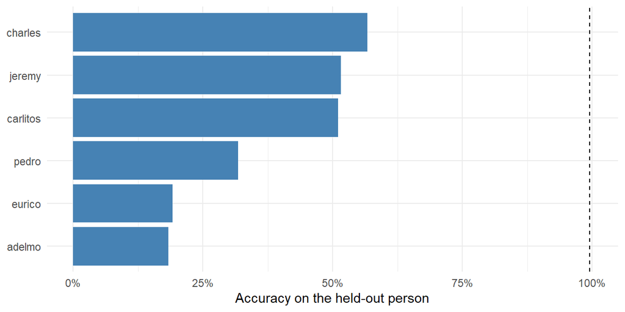

Figure 3. Accuracy on each participant when that participant is left out of training. The dashed line is the validation accuracy for known participants.

```r
ggplot(data.frame(subject = names(loso_accuracy), accuracy = loso_accuracy),
       aes(reorder(subject, accuracy), accuracy)) +
  geom_col(fill = "steelblue") +
  geom_hline(yintercept = accuracy, linetype = "dashed") +
  scale_y_continuous(labels = scales::percent, limits = c(0, 1)) +
  labs(x = NULL, y = "Accuracy on the held-out person") +
  coord_flip() +
  theme_minimal()
```

Accuracy on an unseen person averages 38%, far below the 99.6% for known people. For 2 of the six it is worse than always guessing class A. The likely reason, not tested here, is that raw readings depend on the person as well as on the technique, through body size, strength and how the sensors sat on them. If so, a forest trained on raw readings learns in part what each of the six people looks like. That is harmless for the quiz, but a real coaching app would need more than six people in training, calibration for each new user, or features that describe whole repetitions rather than single readings.

## Predictions for the 20 test cases

The test rows get the same 52 predictors and are classified by the validated random forest.

```r
test_pred <- predict(rf_fit, test[predictors])
knitr::kable(t(data.frame(problem = test$problem_id, prediction = test_pred)))
```

| problem | 1 | 2 | 3 | 4 | 5 | 6 | 7 | 8 | 9 | 10 | 11 | 12 | 13 | 14 | 15 | 16 | 17 | 18 | 19 | 20 |
| --- | --- | --- | --- | --- | --- | --- | --- | --- | --- | --- | --- | --- | --- | --- | --- | --- | --- | --- | --- | --- |
| prediction | B | A | B | A | A | E | D | B | A | A | B | C | B | A | E | E | A | B | B | B |

## Conclusion

A random forest on 52 raw sensor readings, with `mtry` = 7 chosen by 5-fold cross-validation, classifies the five curl techniques with 99.55% accuracy on an untouched validation set. The expected out-of-sample error is **0.45%** (95% CI 0.28% to 0.68%) for new readings from the six people in the study, which is the setting of the 20 test cases. For a person outside the study, expect far more errors. Accuracy on a left-out participant ranged from 18% to 57%.

## Reference

Velloso, E., Bulling, A., Gellersen, H., Ugulino, W. and Fuks, H. (2013). *Qualitative Activity Recognition of Weight Lifting Exercises.* Proceedings of the 4th International Conference in Cooperation with SIGCHI (Augmented Human ’13). Stuttgart, Germany: ACM SIGCHI. Data from the [Weight Lifting Exercise Dataset](http://web.archive.org/web/20161224072740/http:/groupware.les.inf.puc-rio.br/har), used with thanks to the authors.

Built with R version 4.6.1 (2026-06-24 ucrt), caret 7.0.1 and randomForest 4.7.1.2.